# Homework 1

Author

Jason Marchese

Professional wrestling, while not everyone’s cup of tea, is big business. What started as a carnival act has turned into a global entertainment industry. Netflix recently started showing Monday Night Raw, a program from the biggest North American wrestling company, WWE – this deal is reportedly worth $5 billion. Like any large entity, WWE is not without competition, drama, and scandal.

## General Tips

This is very much a step-by-step process. Don’t go crazy trying to get everything done with as few lines as possible. Read the documentation for the AlphaVantage api! Carefully explore the pages from cagematch. There isn’t a need to get too fancy with anything here – just go with simple function and all should be good. Don’t print comments, but use normal text for explanations.

## Step 1

In the `calls` folder, you’ll find 4 text files – these are transcripts from quarterly earnings calls. Read those files in (glob.glob will be very helpful here), with appropriate column names for ticker, quarter, and year columns; this should be done within a single function. Perform any data cleaning that you find necessary.

```python
import glob as glob
import pandas as pd
import regex as re

#import data via glob
data_files= glob.glob("C:/Users/jason/downloads/HD2023/unstructured data anayltics/calls/*")
print(data_files)

def read_calls(data_files):
    data_list = []
    for file in data_files:
        with open(file, "r", encoding="utf-8") as f:
            content = f.read()
            file_name = file.split("/")[-1]
              # Read with UTF-8 encoding
            ticker, quarter, year = file_name.replace(".txt", "").split("_")
            cleaned_content = "".join(content.split())

            data_list.append({
                "ticker": ticker,
                "quarter": quarter,
                "year": year,
                "content": cleaned_content
            })


    df = pd.DataFrame(data_list)

    new_tickers = []
    for ticker in df["ticker"]:
        new_ticker = re.sub(r"[calls\\]", "", ticker)
        new_tickers.append(new_ticker)

    df["ticker"] = new_tickers

    return df

read_calls(data_files)
```

```
['C:/Users/jason/downloads/HD2023/unstructured data anayltics/calls\\edr_q3_2023.txt', 'C:/Users/jason/downloads/HD2023/unstructured data anayltics/calls\\tko_q3_2024.txt', 'C:/Users/jason/downloads/HD2023/unstructured data anayltics/calls\\wwe_q1_2023.txt', 'C:/Users/jason/downloads/HD2023/unstruct…
```

|  | ticker | quarter | year | content |
| --- | --- | --- | --- | --- |
| 0 | edr | q3 | 2023 | CompanyParticipantsJamesMarsh-IRAriEmanuel-CEO... |
| 1 | tko | q3 | 2024 | CompanyParticipantsSethZaslow-HeadofInvestorRe... |
| 2 | wwe | q1 | 2023 | CompanyParticipantsSethZaslow-HeadofIRNickKhan... |
| 3 | wwe | q2 | 2023 | CompanyParticipantsNickKhan-CEOFrankRiddick-CF... |

## Step 2

Use the AlphaVantage api to get daily stock prices for WWE and related tickers for the last 5 years – pay attention to your data. You cannot use any AlphaVantage packages (i.e., you can only use requests to grab the data). Tell me about the general trend that you are seeing. I don’t care which viz package you use, but plotly is solid and plotnine is good for ggplot2 users.

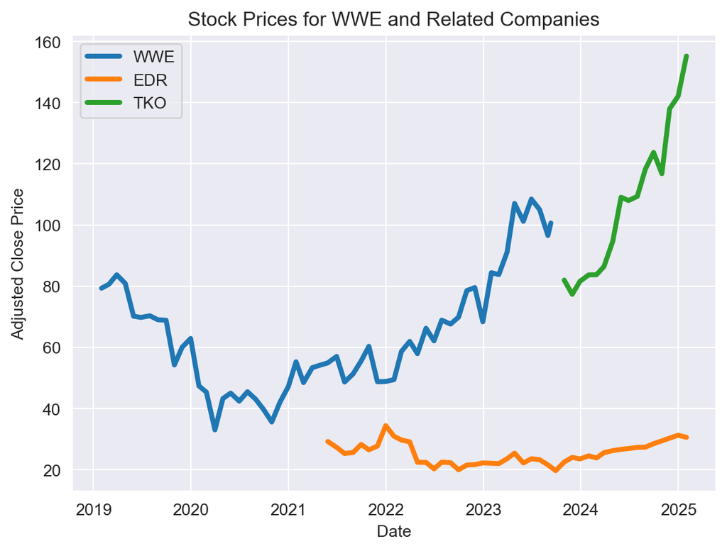

```python
import requests
import seaborn as sns
API_KEY = "6E4YZCJEWJM383Q3"  # Replace with your AlphaVantage API key

# WWE and related companies (adjust if needed)
tickers = ["WWE", "EDR", "TKO"]

# Base URL for AlphaVantage
BASE_URL = "https://www.alphavantage.co/query"

# Dictionary to store stock data
stock_data = {}

for ticker in tickers:

    params = {
        "function": "TIME_SERIES_MONTHLY_ADJUSTED",  #can only get 100 days of data without premium using the daily function
        "symbol": ticker,
        "apikey": API_KEY
    }

    response = requests.get(BASE_URL, params=params)
    data = response.json()

    if "Monthly Adjusted Time Series" in data:
        df = pd.DataFrame.from_dict(data["Monthly Adjusted Time Series"], orient="index")
        df = df.rename(columns={
            "1. open": "open",
            "2. high": "high",
            "3. low": "low",
            "4. close": "close",
            "5. adjusted close": "adjusted_close",
            "6. volume": "volume"
        })

        df.index = pd.to_datetime(df.index)  # Convert index to datetime
        df = df.astype(float)  # Convert values to numeric
        stock_data[ticker] = df  # Store DataFrame

    else:
        print(f"Error fetching data for {ticker}: {data}")


stock_data["WWE"].head()
stock_data["WWE"].tail()

stock_data["EDR"].head()
stock_data["EDR"].tail()

stock_data["TKO"].head()
stock_data["TKO"].tail()
#since wwe data does not go up until present taking the last 5 years of wwe data and overlaying it to the corresponding years in other tickers.

last_5_years_WWE = stock_data["WWE"].loc[pd.Timestamp("2023-09-11"):pd.Timestamp("2019-01-01")]
last_5_years_EDR = stock_data["EDR"].loc[pd.Timestamp("2025-02-03"):pd.Timestamp("2021-05-28")]
last_5_years_TKO = stock_data["TKO"].loc[pd.Timestamp("2025-02-03"):pd.Timestamp("2023-10-31")]

stock_data["WWE"].head()
stock_data["WWE"].tail()

last_5_years_WWE.head()
last_5_years_WWE.tail()
stock_data["TKO"].head()
stock_data["TKO"].tail()


#plotting the data
import matplotlib.pyplot as plt
sns.set_style("darkgrid")
sns.lineplot(data=last_5_years_WWE["adjusted_close"], label="WWE", lw = 3)
sns.lineplot(data=last_5_years_EDR["adjusted_close"], label="EDR", lw = 3)
sns.lineplot(data=last_5_years_TKO["adjusted_close"], label="TKO", lw = 3)
plt.title("Stock Prices for WWE and Related Companies")
plt.ylabel("Adjusted Close Price")
plt.xlabel("Date")

#tko is the mother company of the wwe and ufc.. the ufc stock ticker is not available after 2023 so TKO is the
#closest thing to it.

#EDR is the majority holder of TKO so it is also included in the plot.

#Theres a strong uptrend in the WWE stock which continues in the past year with
#TKO which aquired the WWE
```

## Step 3

Just like every other nerdy hobby, professional wrestling draws dedicated fans. Wrestling fans often go to cagematch.net to leave reviews for matches, shows, and wrestlers. The following link contains the top 100 matches on cagematch: https://www.cagematch.net/?id=111&view=statistics

- What is the correlation between WON ratings and cagematch ratings?

** Which wrestler has the most matches in the top 100?

*** Which promotion has the most matches in the top 100?

**** What is each promotion’s average WON rating?

***** Select any single match and get the comments and ratings for that match into a data frame.

```python
from bs4 import BeautifulSoup
import regex as re

url = "https://www.cagematch.net/?id=111&view=statistics"

response = requests.get(url)

soup = BeautifulSoup(response.text, "html.parser")

table = soup.find("table")

rows = table.find_all("tr")[1:]

match_data = []

for row in rows:
  columns = row.find_all("td")
  if len(columns) < 8:
    continue

  rank = columns[0].text.strip()  # Match rank
  date = columns[1].text.strip()  # Match date
  promotion = columns[2].find("img")["alt"].strip() if columns[2].find("img") else "Unknown"  # Wrestling promotion
  match_name = columns[3].text.strip()  # Wrestlers involved
  WON = columns[4].text.strip() # WON rating
  rating = columns[6].text.strip()  # Cagematch rating
  votes = columns[7].text.strip()  # Number of votes

  match_data.append({
      "Rank": rank,
      "Date": date,
      "Promotion": promotion,
      "Match": match_name,
      "Rating": rating,
      "Votes": votes,
      "WON rating" : WON
    })


df2 = pd.DataFrame(match_data)
df2

def won_rating(WON):
    star_mapping = {
        "****": 4,
        "****1/4" : 4.25,
        "****1/2": 4.5,
        "****3/4": 4.75,
        "*****" : 5,
        "*****1/4": 5.25,
        "*****1/2": 5.5,
        "*****3/4": 5.75,
        "******": 6,
        "******1/4": 6.25,
        "******1/2": 6.5,
        "******3/4": 6.75,
        "*******": 7
    }

    return star_mapping.get(WON, None)

df2["WON rating"] = df2["WON rating"].apply(won_rating)



df2.head()


#what is the correlation between WON ratings and cagematch ratings
won_ratings = df2["WON rating"]
cagematch_ratings = df2["Rating"]
correlation = won_ratings.corr(cagematch_ratings)
correlation #the correlation is 0.35

#which wrestler has the most matches in the top 100
wrestlers = df2["Match"]

wrestler_names = []
for match in df2["Match"]:
    teams = match.split(" vs. ")

    for team in teams:
        wrestlers = re.split(r" & |, ", team)
        wrestler_names.extend(wrestlers)

wrestler_counts = pd.Series(wrestler_names).value_counts()
wrestler_counts.head(1) #kenny omega has the most matches in the top 100 with 15 matches


#which promotion has the most matches in the top 100
promotions = df2["Promotion"].value_counts().head(1)
promotions
#new japan pro wrestling has the most matches in the top 100 with 34

#what is each promotion's average WON rating
df2.groupby("Promotion")["WON rating"].mean().sort_values(ascending=False)


#getting the comments and ratings for a single match
single_match_url = "https://www.cagematch.net/?id=111&nr=8034&page=99"
single_match_response = requests.get(single_match_url)
single_match_soup = BeautifulSoup(single_match_response.text, "html.parser")


# Extract all individual comments inside the section
comment_boxes = single_match_soup.find_all("div", class_="Comment")
comment_boxes

#creating an empty list to store the comments
comments_data = []
#extracting the comments by using a for loop to iterate through the comment boxes
for comment in comment_boxes:
  comment_text = comment.find("div", class_="CommentContents").text.strip()
  comments_data.append({"Comment": comment_text})

#since I appended the comments as a dictionary the col name is already defined
#so I can just convert the list of dictionaries to a dataframe
comments_ratings_df = pd.DataFrame(comments_data)

# Extract ratings from comments
ratings = []
for comment in comments_ratings_df["Comment"]:
    rating = re.findall(r"(\d+)", comment)
    if len(rating) >= 2:  # Ensure at least two numbers exist
        ratings.append(int(rating[0]))  # Convert to integers and store as tuple
    else:
        ratings.append(None)

comments_ratings_df["Rating"] = ratings

new_comments = []
for comment in comments_ratings_df["Comment"]:
    if "]" in comment:
        no_rating = comment.split("]")[1]
        new_comments.append(no_rating)
    else:
        no_rating = comment
        new_comments.append(no_rating)

comments_ratings_df["Comment"] = new_comments

comments_ratings_df
```

|  | Comment | Rating |
| --- | --- | --- |
| 0 | "Agreed with the 6 stars rating but no matter... | 9.0 |
| 1 | "This is a 10 for me all day. This was the mat... | 10.0 |
| 2 | "[******1/2 | 10.0 |
| 3 | "This was the greatest match of all time. I w... | 10.0 |
| 4 | "The match that broke a lot of brains, it is ... | 10.0 |
| ... | ... | ... |
| 319 | "Oh my f***** god this math was simply the mo... | 10.0 |
| 320 | "Okada/Tanahashi last year was said to be one... | 10.0 |
| 321 | "It's no secret everyone had very high expect... | 10.0 |
| 322 | "Expectations for this match were ridiculousl... | 10.0 |
| 323 | "Allein die aufmachung zu diesem Match war so... | 10.0 |

324 rows × 2 columns

## Step 4

You can’t have matches without wrestlers. The following link contains the top 100 wrestlers, according to cagematch: https://www.cagematch.net/?id=2&view=statistics

*** Of the top 100, who has wrestled the most matches?

***** Of the top 100, which wrestler has the best win/loss?

```python
wrestlers_url = "https://www.cagematch.net/?id=2&view=statistics"

wrestlers_response = requests.get(wrestlers_url)

wrestlers_soup =BeautifulSoup(wrestlers_response.text, "html.parser")

wrestlers_table = wrestlers_soup.find("table")

wrestlers_rows = wrestlers_table.find_all("tr")[1:]

wrestlers_data = []

for row in wrestlers_rows:
    columns = row.find_all("td")
    if len(columns) < 8:
        continue

    rank = columns[0].text.strip()  # Wrestler rank
    Gimmick = columns[1].text.strip()  # Wrestler name
    Birthplace = columns[2].text.strip()  # Number of matches
    Height = columns[3].text.strip()  # Number of wins
    Weight = columns[4].text.strip()  # Number of losses
    Promotion = columns[5].text.strip()  # Number of draws
    Rating = columns[6].text.strip()  # Win percentage
    Votes = columns[7].text.strip()  # Cagematch rating

    wrestlers_data.append({
        "rank": rank,
        "Gimmick": Gimmick,
        "Birthplace": Birthplace,
        "Height": Height,
        "Weight": Weight,
        "Promotion": Promotion,
        "Rating": Rating,
        "Votes": Votes
    })

df3 = pd.DataFrame(wrestlers_data)
df3.head()

#which wrestler has wrestled the most matches
link_stats = "https://www.cagematch.net/?id=111&view=matchstatistics"
stats_response = requests.get(link_stats)
stats_soup = BeautifulSoup(stats_response.text, "html.parser")
stats_content = stats_soup.select('div.TableContents tr td')
stats_content

stuff = [stats_content[x].text for x in range(0, len(stats_content))]
print(stuff)

colnames = stuff[:9]
print(colnames)

last_content = stuff[9:]
print(last_content)

rows = []
for i in range(0, len(last_content), 9):
    rows.append(last_content[i:i+9])

print(rows)

win_loss_df = pd.DataFrame(rows, columns=colnames)
win_loss_df

#wrestler with the best win/loss
import numpy as np
win_loss_df.fillna(0, inplace = True)
win_loss_df["Wins"] = pd.to_numeric(win_loss_df["Wins"], errors = "coerce")
win_loss_df["Losses"] = pd.to_numeric(win_loss_df["Losses"], errors = "coerce")
win_loss_df[(win_loss_df["Losses"] == 0) & (win_loss_df["Wins"] > 0)].sort_values("% W", ascending = True).head(10)

win_loss_df
#there are 9 wrestlers with a 100% win rate

#finding which wrestler has the most career matches
link_matches = "https://www.cagematch.net/?id=2&view=statistics"
req = requests.get(link_matches)
soup = BeautifulSoup(req.text, "html.parser")

links = soup.select('div.TableContents tr td a')
links

wrestler_links = [link['href'] for link in links]
wrestler_links

BASE_URL = "https://www.cagematch.net/"



full_links = [BASE_URL + link for link in wrestler_links]
full_links


stats_pages = []
for link in full_links:
    next_link = link.split("&gimmick")[0] + "&page=22"
    stats_pages.append(next_link)
stats_pages


most_matches = []
for i in stats_pages:
    req = requests.get(i)
    soup = BeautifulSoup(req.text, "html.parser")
    stats = soup.select("div.HeaderBox h1.TextHeader, div.InformationBoxContents")

    most_matches.append([stat.get_text(strip = True) for stat in stats])

most_matches

most_matches_df = pd.DataFrame(most_matches, columns = ["Name", "Matches", "Wins", "Losses", "Draws"])
most_matches_df.head()

most_matches_df["Matches"] = pd.to_numeric(most_matches_df["Matches"], errors="coerce")

most_matches_df["Matches"].argmax()
print(f"the wrestler with the most matches is {most_matches_df["Name"][155]} with {most_matches_df["Matches"][155]} matches")
```

[output not shown]

## Step 5

With all of this work out of the way, we can start getting down to strategy.

First, what talent should WWE pursue? Advise carefully.

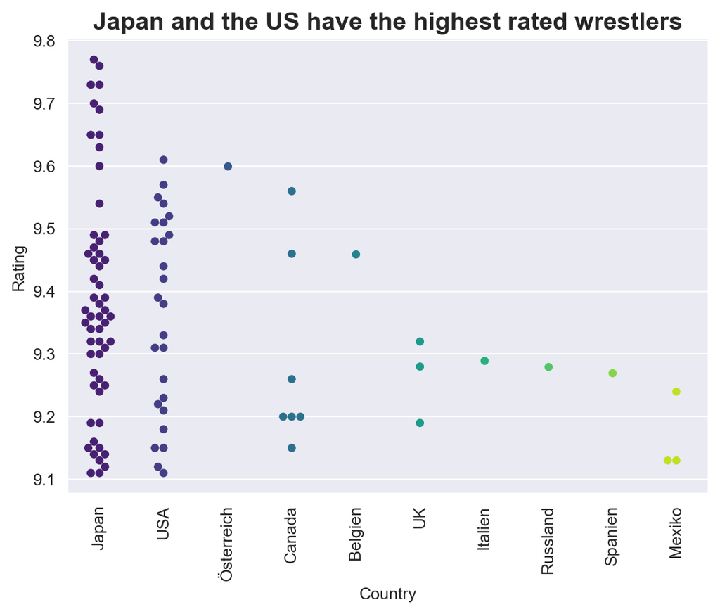

```python
#going to create a new variable country and then find the average rating and won rating from
#wrestlers of from the same country.
df3.head()
#getting the last word in birth place to get the country
df3["Country"] = df3["Birthplace"].str.split().str[-1]
type(df3["Rating"][1])
df3["Rating"] = pd.to_numeric(df3["Rating"], errors = "coerce")
df3.groupby("Country")["Rating"].mean().sort_values(ascending = False)

#creating a swarmplot to view the amout of wrestlers from each country and their average rating
sns.set_style("darkgrid")
sns.swarmplot(data = df3, x = "Country", y = "Rating", hue = "Country", palette = "viridis", dodge = False)
plt.xticks(rotation = 90)
plt.title("Japan and the US have the highest rated wrestlers", fontdict = {"fontsize" : 15, "weight" : "bold"})
```

Second, reconcile what you found in steps 3 and 4 with Netflix’s relationship with WWE. Use the data from the following page to help make your case: https://wrestlenomics.com/tv-ratings/

Since WWE RAW made its netfilx debt viewiership saw a massive spike but fell off in the following weeks. This is not all bad though because the WWE reached a new audience and it expected that the WWE isnt for everyone. Now the WWE has a massive new opportunity to try to retain using strategies like signing more wrestlers from the US and Japan.

Third, do you have any further recommendations for WWE?

recomendations: I think I would be a good idea for the WWE to prioritize US and Japan wrestlers where the most fans reside and try to primary sign talent from those countries. I also think in order to grow the sport it would be logical to sign a few wrestlers from other countries without a strong wrestling presence to try and grow the sport in those countries. If the WWE finds that the wrestlers from those countries gain traction they could then sign more talent from those countries.

A goood example of this can be seen in the swarm plot above where Osterrich has a high average rating but only 1 wrestler from that country. This could be a good opportunity for the WWE to sign more wrestlers from Osterrich and grow the sport in that country. If it becomes a trend that wrestlers from Osterrich are popular then the WWE could sign more talent from that country. Another country that presents a similar opportunity is Belgien.